# Student Report (Week 07 R Markdown Demo)

Sami Cemek

## Introduction

This is a brief report that explores college debt by institution and region for the year 2019 or 2020. We will focus on:

1. Summarizing and visualizing one numerical variable, as well as interpreting the results of those summaries and graphs.
2. Comparing distributions of a numerical variable that has been split into groups (categories) according to a second variable.

Suppose you are intending to present this information at a meeting of other NCF students. Some students will have statistics or R knowledge and some won’t; you want to be able to focus on the results, but still demonstrate transparency if anyone asks about how your code works.

You also want to be able to switch between 2019 and 2020 data easily, since people might want to see the past year or the current year, depending on their interest.

## Data prep

The data we will be working with comes from the College Scorecard website, which you can access here: https://collegescorecard.ed.gov/data/. The data was updated in summer 2019 and contains dozens of variables measured about thousands of colleges across the country.

We have downloaded a smaller version of the data set for this week’s report. We have focused in on a few variables, though you are welcome to look at the larger data set if you are interested in the topic.

Even with the smaller data set, we need to do some work before we can start making graphs of finding numerical summaries. Here is an overview of the variables we will be working with.

The `REGION` variable records the region of US from where each college or institution is located. It consists of

| Abbreviation | Region | States/Areas |
| --- | --- | --- |
| GL | Great Lakes | (IL, IN, MI, OH, WI) |
| ME | Mid East | (DE, DC, MD, NJ, NY, PA) |
| NE | New England | (CT, ME, MA, NH, RI, VT) |
| Outlying | Outlying Area | (AS, FM, GU, MH, MP, PR, PW, VI) |
| Plains | Plains | (IA, KS, MN, MO, NE, ND, SD) |
| Rockies | Rocky Mountains | (CO, ID, MT, UT, WY) |
| SE | Southeast | (AL, AR, FL, GA, KY, LA, MS, NC, SC, TN, VA, WV) |
| SW | Southwest | (AZ, NM, OK, TX) |
| U.S.S.S. | U.S. Service schools |  |
| West | Far West | (AK, CA, HI, NV, OR, WA) |

In addition, we will look at three other variables as well. DEBT_MDN_SUPP is the median debt per institution, which has been suppressed for sample sizes less than 30. COSTT4_A is the annual total cost of attendance. RPY_3YR_RT_SUPP is the 3rd year repayment rate, again suppressed for small sample sizes.

## Results

The results section is broken into 4 sub-sections. First, we look at overall median debt across all schools. Then we break the analysis of cost down by region, take a closer look at students’ abilities to repay their debts, and finally we examine at how NCF compares to other schools.

### Median Debt for 2019, across all schools

Let’s consider the median debt at the schools in the data set. Here are numerical summaries and graphs for the distribution of debt. Describe the main features of the distribution.

```r
favstats(~DEBT_MDN_SUPP, data = college)
```

```
##   min   Q1 median    Q3   max    mean       sd    n missing
##  1090 7000   9500 14765 39000 11271.2 5472.106 5855    1260
```

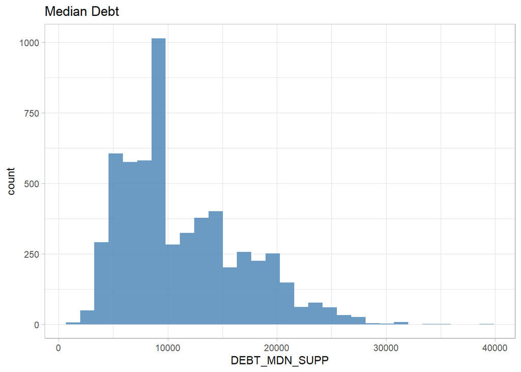

```r
gf_histogram(~DEBT_MDN_SUPP, data = college, bins = 30, fill = "steelblue", alpha = 0.8) +
  labs(title = paste("Median Debt")) + theme_light()
```

### Cost by Region

```r
favstats(COSTT4_A ~ REGION, data = college)
```

```
##      REGION  min       Q1  median       Q3   max     mean        sd   n missing
## 1        GL    0 14086.75 24064.5 37594.50 72717 26881.25 14298.302 516     537
## 2        ME 8599 19147.00 25885.0 43832.00 72120 31492.47 16496.254 605     519
## 3        NE 9021 19058.00 35945.0 53516.50 69474 37401.27 19341.777 219     172
## 4  Outlying 3930  9598.00 11322.0 13136.00 23124 11528.06  3128.374 101      55
## 5    Plains 7050 15499.00 21481.0 33556.00 69754 25236.54 12550.988 357     227
## 6   Rockies 9250 14088.00 19615.0 27238.00 66400 22250.76 10631.092 125     142
## 7        SE 5185 13493.50 22440.0 30219.75 93704 24201.47 12587.604 914     874
## 8        SW 6787 12235.25 18649.0 26470.50 69358 21330.38 11506.394 308     441
## 9   U.S.S.S 8429  8429.00  8429.0  8429.00  8429  8429.00        NA   1       6
## 10     West 8127 12981.50 20940.0 35271.25 71917 26538.90 16593.443 438     558
```

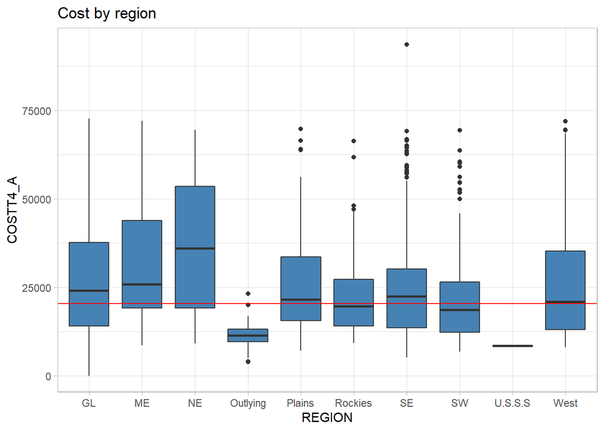

```r
gf_boxplot(COSTT4_A ~ REGION, data = college, fill = "steelblue")%>%
        gf_hline(color = "red",
                yintercept = unlist(ncf_val[1, "COSTT4_A"]),
                data = NA) +
  theme_light() +
  labs(title = paste("Cost by region"))
```

As we can see from the above summaries, the SouthEast (where NCF is located) had some of the highest costing colleges, with outliers far above the rest of the institutions. The schools with the overall highest and lowest cost in 2019 were:

```r
college %>%
  filter(COSTT4_A %in% c(min(COSTT4_A, na.rm = TRUE), max(COSTT4_A, na.rm = TRUE))) %>%
  mutate(COST = paste0("$", COSTT4_A)) %>%
  select(INSTNM, REGION, COST)
```

```
## # A tibble: 2 x 3
##   INSTNM                                                 REGION COST
##   <chr>                                                  <chr>  <chr>
## 1 Aviator College of Aeronautical Science and Technology SE     $93704
## 2 Purdue University Northwest                            GL     $0
```

### Debt Repayment

Let’s consider students’ ability to repay their debt within 3 years, broken down by region. The following show summaries and graphs to describe the distribution of repayment rates by region. Compare the regions. (Also pay attention to sample size!)

```r
favstats(RPY_3YR_RT_SUPP~REGION, data = college)
```

```
##      REGION        min        Q1    median        Q3       max      mean
## 1        GL 0.09589041 0.2982269 0.4193548 0.5782273 0.9330335 0.4452101
## 2        ME 0.08333333 0.3632695 0.5000000 0.6574627 0.9332024 0.5072275
## 3        NE 0.21523438 0.4495787 0.5775334 0.7149760 0.9182283 0.5780249
## 4  Outlying 0.28028249 0.3635097 0.4429158 0.5438979 0.7575758 0.4629775
## 5    Plains 0.12612613 0.3668589 0.5015115 0.6453796 0.9336735 0.5082454
## 6   Rockies 0.11691023 0.3435099 0.4626200 0.5857501 0.9055184 0.4705851
## 7        SE 0.09893993 0.2589162 0.3601533 0.5085573 0.8887994 0.3936048
## 8        SW 0.06737589 0.2744127 0.3597467 0.4626200 0.8716707 0.3814479
## 9   U.S.S.S         NA        NA        NA        NA        NA       NaN
## 10     West 0.17226891 0.3270977 0.4372829 0.5659695 0.9298246 0.4613930
##           sd    n missing
## 1  0.1834770  871     182
## 2  0.1843508  906     218
## 3  0.1787427  338      53
## 4  0.1194142   52     104
## 5  0.1819779  504      80
## 6  0.1649521  224      43
## 7  0.1683897 1363     425
## 8  0.1499030  578     171
## 9         NA    0       7
## 10 0.1662172  784     212
```

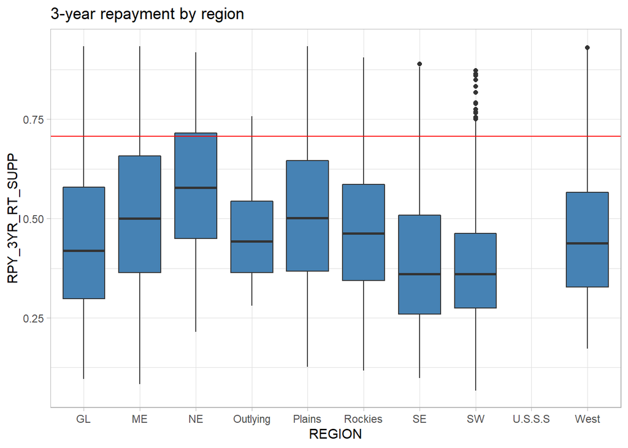

```r
gf_boxplot(RPY_3YR_RT_SUPP~REGION, data = college, fill = "steelblue")%>%
        gf_hline(color = "red",
                yintercept = unlist(ncf_val[1, "RPY_3YR_RT_SUPP"]),
                data = NA) +
  theme_light() +
  labs(title = paste("3-year repayment by region"))
```

Here, we see a large amount of variation in the schools across all regions. The schools with the lowest and highest repayment rates are shown below:

```r
college %>%
  filter(RPY_3YR_RT_SUPP %in% c(min(RPY_3YR_RT_SUPP, na.rm = TRUE), max(RPY_3YR_RT_SUPP, na.rm = TRUE))) %>%
  mutate(REPAY_RATE = paste0(round(100*RPY_3YR_RT_SUPP,2), "%")) %>%
  select(INSTNM, REGION, REPAY_RATE)
```

```
## # A tibble: 3 x 3
##   INSTNM                        REGION REPAY_RATE
##   <chr>                         <chr>  <chr>
## 1 St. Louis College of Pharmacy Plains 93.37%
## 2 Trend Barber College          SW     6.74%
## 3 Trend Barber College          SW     6.74%
```

### A Closer look at New College

Now look more deeply into the data. Find New College in the data set. Look at the 6 year median earnings and median debt. How does New College stack up to other schools across the country and in the Southeast?

```
## # A tibble: 1 x 5
##   INSTNM                 REGION COSTT4_A DEBT_MDN_SUPP RPY_3YR_RT_SUPP
##   <chr>                  <chr>     <dbl>         <dbl>           <dbl>
## 1 New College of Florida SE        20395         9798.           0.707
```

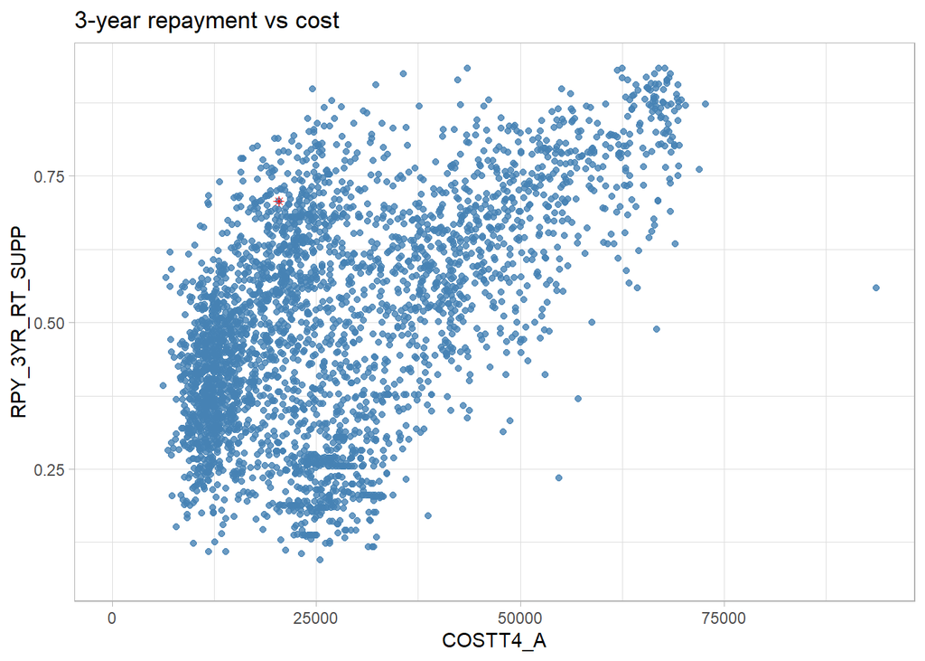

```r
gf_point(RPY_3YR_RT_SUPP ~ COSTT4_A, data = college, color = "steelblue", alpha = 0.8) %>%
        gf_point(RPY_3YR_RT_SUPP ~ COSTT4_A, color = "red", shape = 8, data = ncf_val)+
  theme_light() +
  labs(title = paste("3-year repayment vs cost"))
```

The graph shows that NCF has a lower cost and higher repayment rate than most colleges in the U.S.

[figure not shown]